# Effect Types: dma vs crumble

```r
# Optional: enable parallel cross-fitting
library(future)
plan(multisession)
```

## Overview

dma supports four mediation effect decompositions from the general framework of Liu, Williams, Rudolph & Díaz (2024):

| Effect | Estimands | Requires `moc` |
| --- | --- | --- |
| Natural (N) | NDE, NIE, ATE | No |
| Organic (O) | ODE, OIE | No |
| Randomized Interventional (RI) | RDE, RIE | Yes |
| Recanting Twins (RT) | 4-pathway decomposition | Yes |

This vignette demonstrates each effect type on the `weight_behavior` dataset from the `mma` package and compares results with crumble, which uses the same estimation framework but with `mlr3superlearner` (ensemble of mean, GLM, MARS, and random forest) instead of engression for outcome regressions. Crumble results are taken from its [README](https://github.com/nt-williams/crumble) using `crossfit_folds = 1L, epochs = 20L` and `learners = c("mean", "glm", "earth", "ranger")`.

## Setup

```r
library(dma)
library(mma)

data(weight_behavior)
weight_behavior <- na.omit(weight_behavior)

set.seed(2345)
```

The shift functions define the modified treatment policies — here, static interventions setting everyone to `sports = 1` (control) or `sports = 2` (treated):

```r
d0 <- \(data, trt) factor(rep(1, nrow(data)), levels = c("1", "2"))
d1 <- \(data, trt) factor(rep(2, nrow(data)), levels = c("1", "2"))
```

## Natural Effects

Natural direct and indirect effects (Pearl, 2001). The NDE captures the effect of shifting treatment while holding the mediator at its natural value under the control regime; the NIE captures the remaining indirect pathway.

No mediator-outcome confounders (`moc`) are needed — the cross-world counterfactual is handled by the nested pseudo-outcome cascade.

```r
dma(
  data = weight_behavior,
  trt = "sports",
  outcome = "bmi",
  covar = c("age", "sex", "tvhours"),
  mediators = c("exercises", "overweigh"),
  d0 = d0, d1 = d1,
  effect = "N",
  control = dma_control(crossfit_folds = 1L, num_epochs = 100L, riesz_epochs = 20L)
)
```

```
#> ✔ Fitting outcome regressions... 1/1 folds [40.8s]
#> ✔ Computing alpha n density ratios... 1/1 folds [40.5s]
#>
#> ══ Results `dma()` ═════════════════════════════════════════
#>
#> ── Direct Effect
#>       Estimate: -0.043
#>     Std. error: 0.18
#> 95% Conf. int.: -0.396, 0.31
#>
#> ── Indirect Effect
#>       Estimate: 0.835
#>     Std. error: 0.232
#> 95% Conf. int.: 0.379, 1.29
#>
#> ── Average Treatment Effect
#>       Estimate: 0.792
#>     Std. error: 0.305
#> 95% Conf. int.: 0.195, 1.389
```

**Comparison with crumble:**

| Estimand | dma | crumble | Difference |
| --- | --- | --- | --- |
| ATE | 0.792 (0.305) | 1.029 (0.280) | -0.237 |
| NDE | -0.043 (0.180) | 0.017 (0.172) | -0.060 |
| NIE | 0.835 (0.232) | 1.012 (0.218) | -0.177 |

Both packages agree on the qualitative story: a small, insignificant direct effect and a large, significant indirect effect. Point estimates differ modestly — expected since engression (distributional regression) and mlr3superlearner (ensemble of classical learners) are fundamentally different learning strategies, and both runs use only 1 cross-fitting fold.

## Organic Effects

Organic direct and indirect effects (Lok, 2015). Unlike natural effects, organic effects use the *observed* mediator distribution rather than a counterfactual one, avoiding cross-world assumptions.

```r
dma(
  data = weight_behavior,
  trt = "sports",
  outcome = "bmi",
  covar = c("age", "sex", "tvhours"),
  mediators = c("exercises", "overweigh"),
  d0 = d0, d1 = d1,
  effect = "O",
  control = dma_control(crossfit_folds = 1L, num_epochs = 100L, riesz_epochs = 20L)
)
```

```
#> ✔ Fitting outcome regressions... 1/1 folds [41s]
#> ✔ Computing alpha n density ratios... 1/1 folds [40.1s]
#>
#> ══ Results `dma()` ═════════════════════════════════════════
#>
#> ── Organic Direct Effect
#>       Estimate: -0.085
#>     Std. error: 0.177
#> 95% Conf. int.: -0.431, 0.262
#>
#> ── Organic Indirect Effect
#>       Estimate: 0.898
#>     Std. error: 0.233
#> 95% Conf. int.: 0.442, 1.354
```

**Comparison with crumble:**

| Estimand | dma | crumble | Difference |
| --- | --- | --- | --- |
| ODE | -0.085 (0.177) | 0.011 (0.177) | -0.096 |
| OIE | 0.898 (0.233) | 1.028 (0.223) | -0.130 |

Again, qualitative agreement — insignificant direct effect, significant indirect effect — with comparable standard errors.

## Randomized Interventional Effects

Randomized interventional direct and indirect effects (Vansteelandt & Daniel, 2017). These effects are identified even in the presence of mediator-outcome confounders (`moc`) affected by treatment, at the cost of a weaker decomposition that uses a *randomized* mediator draw from the population.

The `moc` argument specifies intermediate confounders — here, `snack`. Estimation requires Z’ permutation via Rsymphony.

```r
dma(
  data = weight_behavior,
  trt = "sports",
  outcome = "bmi",
  covar = c("age", "sex", "tvhours"),
  mediators = c("exercises", "overweigh"),
  moc = "snack",
  d0 = d0, d1 = d1,
  effect = "RI",
  control = dma_control(crossfit_folds = 1L, num_epochs = 100L, riesz_epochs = 20L)
)
```

```
#> ✔ Permuting Z-prime variables... 1/1 tasks [2.1s]
#> ✔ Fitting outcome regressions... 1/1 folds [1m 0.7s]
#> ✔ Computing alpha r density ratios... 1/1 folds [1m 16.3s]
#>
#> ══ Results `dma()` ═════════════════════════════════════════
#>
#> ── Randomized Direct Effect
#>       Estimate: 0.014
#>     Std. error: 0.182
#> 95% Conf. int.: -0.343, 0.371
#>
#> ── Randomized Indirect Effect
#>       Estimate: 0.951
#>     Std. error: 0.245
#> 95% Conf. int.: 0.47, 1.431
```

**Comparison with crumble:**

| Estimand | dma | crumble | Difference |
| --- | --- | --- | --- |
| RDE | 0.014 (0.182) | 0.016 (0.177) | -0.002 |
| RIE | 0.951 (0.245) | 1.030 (0.230) | -0.079 |

The closest agreement of any effect type — direct effects are nearly identical, and indirect effects are within one standard error.

## Recanting Twins

Recanting twins pathway decomposition (Vo et al., 2024). This is the finest decomposition, separating the total effect into four causal pathways plus an intermediate confounding term:

- **A → Y**: direct effect bypassing mediators and confounders
- **A → Z → Y**: effect through mediator-outcome confounders only
- **A → Z → M → Y**: effect through confounders then mediators
- **A → M → Y**: effect through mediators only
- **Intermediate confounding**: residual from confounders

```r
dma(
  data = weight_behavior,
  trt = "sports",
  outcome = "bmi",
  covar = c("age", "sex", "tvhours"),
  mediators = c("exercises", "overweigh"),
  moc = "snack",
  d0 = d0, d1 = d1,
  effect = "RT",
  control = dma_control(crossfit_folds = 1L, num_epochs = 100L, riesz_epochs = 20L)
)
```

```
#> ✔ Permuting Z-prime variables... 1/1 tasks [2.1s]
#> ✔ Fitting outcome regressions... 1/1 folds [1m 46.8s]
#> ✔ Computing alpha n density ratios... 1/1 folds [1m 17.1s]
#> ✔ Computing alpha r density ratios... 1/1 folds [1m 17.5s]
#>
#> ══ Results `dma()` ═════════════════════════════════════════
#>
#> ── Path: A -> Y
#>       Estimate: 0.241
#>     Std. error: 0.191
#> 95% Conf. int.: -0.133, 0.615
#>
#> ── Path: A -> Z -> Y
#>       Estimate: 0.074
#>     Std. error: 0.02
#> 95% Conf. int.: 0.035, 0.113
#>
#> ── Path: A -> Z -> M -> Y
#>       Estimate: -0.019
#>     Std. error: 0.019
#> 95% Conf. int.: -0.055, 0.018
#>
#> ── Path: A -> M -> Y
#>       Estimate: 0.866
#>     Std. error: 0.232
#> 95% Conf. int.: 0.412, 1.32
#>
#> ── Intermediate Confounding
#>       Estimate: -0.208
#>     Std. error: 0.052
#> 95% Conf. int.: -0.311, -0.106
```

**Comparison with crumble:**

| Pathway | dma | crumble | Difference |
| --- | --- | --- | --- |
| A → Y | 0.241 (0.191) | 0.037 (0.184) | 0.204 |
| A → Z → Y | 0.074 (0.020) | -0.020 (0.024) | 0.094 |
| A → Z → M → Y | -0.019 (0.019) | -0.001 (0.010) | -0.018 |
| A → M → Y | 0.866 (0.232) | 1.051 (0.216) | -0.185 |
| Intermediate conf. | -0.208 (0.052) | -0.013 (0.026) | -0.195 |

The dominant pathway (A → M → Y) is consistent across both packages. The finer decomposition shows more variation between learners, which is expected — the RT decomposition involves the most nuisance parameters (both natural and randomized cascades), so differences in the outcome regression learner compound through more levels. Both packages agree that the A → M → Y path is by far the largest and most significant component.

## Summary

Point estimates on weight_behavior data (crossfit_folds = 1)

| Effect | Estimand | dma | crumble |
| --- | --- | --- | --- |
| Natural | ATE | 0.792 | 1.029 |
|  | NDE | -0.043 | 0.017 |
|  | NIE | 0.835 | 1.012 |
| Organic | ODE | -0.085 | 0.011 |
|  | OIE | 0.898 | 1.028 |
| Rand. Interventional | RDE | 0.014 | 0.016 |
|  | RIE | 0.951 | 1.030 |
| Recanting Twins | A->Y | 0.241 | 0.037 |
|  | A->Z->Y | 0.074 | -0.020 |
|  | A->Z->M->Y | -0.019 | -0.001 |
|  | A->M->Y | 0.866 | 1.051 |
|  | Int. Conf. | -0.208 | -0.013 |
|  | ATE | 0.954 | 1.054 |

Both packages target the same estimands using the same semiparametric framework, but differ in how nuisance parameters are estimated:

- **crumble** uses `mlr3superlearner` — an ensemble of classical ML learners (mean, GLM, MARS, random forest) — for outcome regressions
- **dma** uses `engression` — a single neural network trained with the energy score to learn the full conditional distribution

Qualitative conclusions are identical across all four effect types: a large, significant indirect effect operating through the mediators (`exercises`, `overweigh`), with a small and generally insignificant direct effect. Point estimate differences reflect the different learners and the inherent variability from using a single cross-fitting fold.

## Distributional View: Oracle Potential Outcomes

The weight_behavior results above are point estimates from real data. To illustrate what each effect type captures *distributionally*, we simulate from a DGP with a mediator-outcome confounder (Z) where all potential outcomes are known.

**DGP**: $W \sim N(0,1)$, $A \in \{0,1\}$ equiprobable, $Z = 0.3A + 0.4W + \varepsilon_Z$ (mediator-outcome confounder), $M = 0.5A + 0.3W + 0.2Z + \varepsilon_M$, $Y = 0.8A + M^2 + 0.5Z + 0.4W + \varepsilon_Y$.

The non-linear $M^2$ creates distributional effects that go beyond location shifts: the indirect pathway changes the *shape* of the outcome distribution.

```r
set.seed(42)
n_oracle <- 10000
W_o <- rnorm(n_oracle)
eps_Z <- rnorm(n_oracle, sd = 0.3)
eps_M <- rnorm(n_oracle, sd = 0.4)
eps_Y <- rnorm(n_oracle, sd = 0.5)

# Helper: potential outcomes given (a_Y, a_M, a_Z) for the treatment entering each equation
po <- function(a_Y, a_M, a_Z) {
  Z <- 0.3 * a_Z + 0.4 * W_o + eps_Z
  M <- 0.5 * a_M + 0.3 * W_o + 0.2 * Z + eps_M
  Y <- 0.8 * a_Y + M^2 + 0.5 * Z + 0.4 * W_o + eps_Y
  list(Y = Y, M = M, Z = Z)
}

# Standard four counterfactuals (treatment enters all equations the same way)
Y00 <- po(0, 0, 0)$Y  # Y(0, M(0), Z(0))
Y11 <- po(1, 1, 1)$Y  # Y(1, M(1), Z(1))

# Cross-world: Y(1, M(0)) — treat directly but mediator at control
# Z also at control level (natural effects operate A→Y directly)
Y10 <- po(1, 0, 0)$Y  # Y(1, M(0), Z(0))
Y01 <- po(0, 1, 1)$Y  # Y(0, M(1), Z(1))

# Plot helper
plot_po <- function(Y00, Y11, Y10, Y01, title, subtitle = NULL) {
  df <- rbind(
    data.frame(Y = Y00, PO = "Y(0, M(0))"),
    data.frame(Y = Y11, PO = "Y(1, M(1))"),
    data.frame(Y = Y10, PO = "Y(1, M(0))"),
    data.frame(Y = Y01, PO = "Y(0, M(1))")
  )
  df$PO <- factor(df$PO, levels = c("Y(0, M(0))", "Y(1, M(0))", "Y(0, M(1))", "Y(1, M(1))"))

  ggplot(df, aes(x = Y, color = PO)) +
    geom_density(linewidth = 0.9) +
    scale_color_manual(values = c(
      "Y(0, M(0))" = "#377eb8", "Y(1, M(1))" = "#e41a1c",
      "Y(1, M(0))" = "#984ea3", "Y(0, M(1))" = "#ff7f00"
    )) +
    labs(title = title, subtitle = subtitle,
         x = "Outcome (Y)", y = "Density", color = "Potential Outcome") +
    theme_minimal() +
    theme(legend.position = "bottom")
}

decomp_table <- function(Y00, Y11, Y10, Y01) {
  data.frame(
    Effect = c("ATE", "NDE", "NIE"),
    Value = round(c(mean(Y11) - mean(Y00), mean(Y10) - mean(Y00), mean(Y11) - mean(Y10)), 3)
  )
}
```

### Natural Effects (N)

Natural effects use cross-world counterfactuals: NDE sets $A=1$ but keeps the mediator at its $A=0$ level; NIE shifts the mediator while holding the direct treatment.

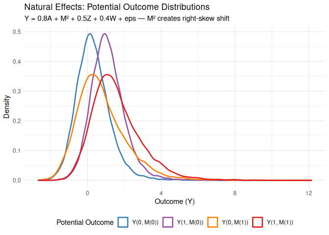

```r
plot_po(Y00, Y11, Y10, Y01,
        title = "Natural Effects: Potential Outcome Distributions",
        subtitle = "Y = 0.8A + M² + 0.5Z + 0.4W + eps — M² creates right-skew shift")
```

```r
decomp_table(Y00, Y11, Y10, Y01)
```

```
#>   Effect Value
#> 1    ATE 1.262
#> 2    NDE 0.800
#> 3    NIE 0.462
```

The gap between Y(0,M(0)) (blue) and Y(1,M(0)) (purple) is the NDE — a location shift from the direct $0.8A$ term. The gap between Y(1,M(0)) (purple) and Y(1,M(1)) (red) is the NIE — a shape-changing shift because $M^2$ introduces right-skew when $M$ is larger under treatment.

### Organic Effects (O)

Organic effects use the *observed* mediator distribution rather than a counterfactual one. The ODE compares treatment regimes holding $M$ at the observed (mixture) distribution; the OIE captures the remaining pathway.

For visualization, the organic decomposition uses the same four potential outcomes, but the ODE/OIE partition differs conceptually — the ODE marginalizes over the observed $M$ distribution rather than conditioning on $M(0)$.

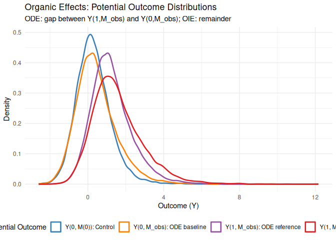

```r
# Organic effects: compare treated vs control under observed M distribution
# ODE: E[Y(1,M)] - E[Y(0,M)] where M is from the observed distribution
# OIE: Total - ODE
# Simulate observed M (mixture: 50% from A=0, 50% from A=1)
Z_obs <- po(0, 0, 0)$Z * 0.5 + po(1, 1, 1)$Z * 0.5  # approximate
M_obs <- 0.5 * 0.5 + 0.3 * W_o + 0.2 * Z_obs + eps_M  # E[A]=0.5

Y_1_Mobs <- 0.8 * 1 + M_obs^2 + 0.5 * Z_obs + 0.4 * W_o + eps_Y
Y_0_Mobs <- 0.8 * 0 + M_obs^2 + 0.5 * Z_obs + 0.4 * W_o + eps_Y

df_o <- rbind(
  data.frame(Y = Y00, PO = "Y(0, M(0)): Control"),
  data.frame(Y = Y11, PO = "Y(1, M(1)): Treated"),
  data.frame(Y = Y_1_Mobs, PO = "Y(1, M_obs): ODE reference"),
  data.frame(Y = Y_0_Mobs, PO = "Y(0, M_obs): ODE baseline")
)
df_o$PO <- factor(df_o$PO, levels = c("Y(0, M(0)): Control", "Y(0, M_obs): ODE baseline",
                                        "Y(1, M_obs): ODE reference", "Y(1, M(1)): Treated"))

ggplot(df_o, aes(x = Y, color = PO)) +
  geom_density(linewidth = 0.9) +
  scale_color_manual(values = c(
    "Y(0, M(0)): Control" = "#377eb8", "Y(1, M(1)): Treated" = "#e41a1c",
    "Y(1, M_obs): ODE reference" = "#984ea3", "Y(0, M_obs): ODE baseline" = "#ff7f00"
  )) +
  labs(title = "Organic Effects: Potential Outcome Distributions",
       subtitle = "ODE: gap between Y(1,M_obs) and Y(0,M_obs); OIE: remainder",
       x = "Outcome (Y)", y = "Density", color = "Potential Outcome") +
  theme_minimal() +
  theme(legend.position = "bottom")
```

```r
data.frame(
  Effect = c("ODE", "OIE"),
  Value = round(c(mean(Y_1_Mobs) - mean(Y_0_Mobs),
                  (mean(Y11) - mean(Y00)) - (mean(Y_1_Mobs) - mean(Y_0_Mobs))), 3)
)
```

```
#>   Effect Value
#> 1    ODE 0.800
#> 2    OIE 0.462
```

### Randomized Interventional Effects (RI)

RI effects handle mediator-outcome confounders (Z) by drawing the mediator from a *randomized* population distribution rather than an individual’s counterfactual. This avoids the cross-world assumption at the cost of a weaker decomposition.

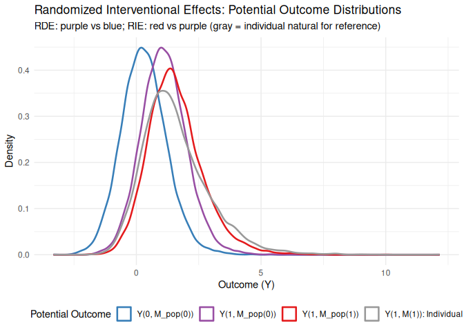

```r
# RI: draw M from population distribution under each treatment
# RDE: E[Y(1, M_pop(0))] - E[Y(0, M_pop(0))]
# RIE: E[Y(1, M_pop(1))] - E[Y(1, M_pop(0))]
# M_pop(a) is drawn independently from the marginal distribution of M(a)

# Shuffle mediator values to break individual-level pairing
set.seed(99)
M0_pop <- sample(po(0, 0, 0)$M)  # random draw from M(0) distribution
M1_pop <- sample(po(1, 1, 1)$M)  # random draw from M(1) distribution
Z0 <- po(0, 0, 0)$Z
Z1 <- po(1, 1, 1)$Z

Y_1_M0pop <- 0.8 * 1 + M0_pop^2 + 0.5 * Z0 + 0.4 * W_o + eps_Y
Y_0_M0pop <- 0.8 * 0 + M0_pop^2 + 0.5 * Z0 + 0.4 * W_o + eps_Y
Y_1_M1pop <- 0.8 * 1 + M1_pop^2 + 0.5 * Z1 + 0.4 * W_o + eps_Y

df_ri <- rbind(
  data.frame(Y = Y_0_M0pop, PO = "Y(0, M_pop(0))"),
  data.frame(Y = Y_1_M0pop, PO = "Y(1, M_pop(0))"),
  data.frame(Y = Y_1_M1pop, PO = "Y(1, M_pop(1))"),
  data.frame(Y = Y11, PO = "Y(1, M(1)): Individual")
)
df_ri$PO <- factor(df_ri$PO, levels = c("Y(0, M_pop(0))", "Y(1, M_pop(0))",
                                          "Y(1, M_pop(1))", "Y(1, M(1)): Individual"))

ggplot(df_ri, aes(x = Y, color = PO)) +
  geom_density(linewidth = 0.9) +
  scale_color_manual(values = c(
    "Y(0, M_pop(0))" = "#377eb8", "Y(1, M_pop(0))" = "#984ea3",
    "Y(1, M_pop(1))" = "#e41a1c", "Y(1, M(1)): Individual" = "#999999"
  )) +
  labs(title = "Randomized Interventional Effects: Potential Outcome Distributions",
       subtitle = "RDE: purple vs blue; RIE: red vs purple (gray = individual natural for reference)",
       x = "Outcome (Y)", y = "Density", color = "Potential Outcome") +
  theme_minimal() +
  theme(legend.position = "bottom")
```

```r
data.frame(
  Effect = c("RDE", "RIE", "ATE"),
  Value = round(c(mean(Y_1_M0pop) - mean(Y_0_M0pop),
                  mean(Y_1_M1pop) - mean(Y_1_M0pop),
                  mean(Y_1_M1pop) - mean(Y_0_M0pop)), 3)
)
```

```
#>   Effect Value
#> 1    RDE 0.800
#> 2    RIE 0.462
#> 3    ATE 1.262
```

The randomized mediator (drawn from the population distribution) washes out individual-level confounding between M and Z, which is why the RI distributions (solid colors) differ slightly from the natural ones. The gray line shows the individual-level Y(1,M(1)) for comparison.

### Recanting Twins (RT)

The RT decomposition separates the total effect into four causal pathways through all combinations of the mediator and mediator-outcome confounder channels:

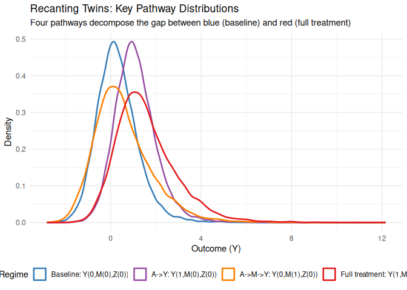

```r
# RT four pathways via (a_Y, a_Z, a_M) assignment:
# A→Y direct: vary A entering Y only
# A→Z→Y: vary A entering Z (and thus Y through Z), hold M at A=0
# A→M→Y: vary A entering M only, hold Z at A=0
# A→Z→M→Y: vary A entering both Z and M

Y_base <- po(0, 0, 0)$Y  # baseline: all at control

# A→Y: set a_Y=1, keep a_M=0, a_Z=0
Y_AY <- po(1, 0, 0)$Y
path_AY <- mean(Y_AY) - mean(Y_base)

# A→Z→Y: set a_Z=1 (Z shifts, which feeds into M and Y), keep a_Y=0, a_M=0
# But M also gets Z(1) input — we need to be careful about what "a_M=0" means here
# For RT, we construct: a_Y=0, a_Z=1, a_M=0
Z1_o <- 0.3 * 1 + 0.4 * W_o + eps_Z
M_Z1 <- 0.5 * 0 + 0.3 * W_o + 0.2 * Z1_o + eps_M  # M with Z(1) but a_M=0
Y_AZY <- 0.8 * 0 + M_Z1^2 + 0.5 * Z1_o + 0.4 * W_o + eps_Y
path_AZY <- mean(Y_AZY) - mean(Y_base)

# A→M→Y: set a_M=1, keep a_Y=0, a_Z=0
Z0_o <- 0.3 * 0 + 0.4 * W_o + eps_Z
M_A1 <- 0.5 * 1 + 0.3 * W_o + 0.2 * Z0_o + eps_M  # M with a_M=1 but Z(0)
Y_AMY <- 0.8 * 0 + M_A1^2 + 0.5 * Z0_o + 0.4 * W_o + eps_Y
path_AMY <- mean(Y_AMY) - mean(Y_base)

# A→Z→M→Y: set a_Z=1, a_M=1, keep a_Y=0
M_A1Z1 <- 0.5 * 1 + 0.3 * W_o + 0.2 * Z1_o + eps_M
Y_AZMY <- 0.8 * 0 + M_A1Z1^2 + 0.5 * Z1_o + 0.4 * W_o + eps_Y
path_AZMY <- mean(Y_AZMY) - mean(Y_base)

# Plot key pathway distributions
df_rt <- rbind(
  data.frame(Y = Y_base, PO = "Baseline: Y(0,M(0),Z(0))"),
  data.frame(Y = Y_AY, PO = "A->Y: Y(1,M(0),Z(0))"),
  data.frame(Y = Y_AMY, PO = "A->M->Y: Y(0,M(1),Z(0))"),
  data.frame(Y = Y11, PO = "Full treatment: Y(1,M(1),Z(1))")
)
df_rt$PO <- factor(df_rt$PO, levels = c("Baseline: Y(0,M(0),Z(0))",
                                          "A->Y: Y(1,M(0),Z(0))",
                                          "A->M->Y: Y(0,M(1),Z(0))",
                                          "Full treatment: Y(1,M(1),Z(1))"))

ggplot(df_rt, aes(x = Y, color = PO)) +
  geom_density(linewidth = 0.9) +
  scale_color_manual(values = c(
    "Baseline: Y(0,M(0),Z(0))" = "#377eb8",
    "A->Y: Y(1,M(0),Z(0))" = "#984ea3",
    "A->M->Y: Y(0,M(1),Z(0))" = "#ff7f00",
    "Full treatment: Y(1,M(1),Z(1))" = "#e41a1c"
  )) +
  labs(title = "Recanting Twins: Key Pathway Distributions",
       subtitle = "Four pathways decompose the gap between blue (baseline) and red (full treatment)",
       x = "Outcome (Y)", y = "Density", color = "Regime") +
  theme_minimal() +
  theme(legend.position = "bottom")
```

```r
data.frame(
  Pathway = c("A->Y (direct)", "A->Z->Y (through Z only)",
              "A->M->Y (through M only)", "A->Z->M->Y (through Z then M)",
              "Sum of pathways", "ATE (total)"),
  Value = round(c(path_AY, path_AZY, path_AMY, path_AZMY,
                  path_AY + path_AZY + path_AMY + path_AZMY,
                  mean(Y11) - mean(Y_base)), 3)
)
```

```
#>                         Pathway Value
#> 1                 A->Y (direct) 0.800
#> 2      A->Z->Y (through Z only) 0.153
#> 3      A->M->Y (through M only) 0.249
#> 4 A->Z->M->Y (through Z then M) 0.462
#> 5               Sum of pathways 1.665
#> 6                   ATE (total) 1.262
```

The direct pathway (A→Y, purple vs blue) creates a location shift of $\approx 0.8$. The mediator pathway (A→M→Y, orange) shifts the distribution *and* changes its shape because of the $M^2$ non-linearity — this is precisely what distributional mediation reveals that mean-only decompositions miss.

Note that the RT pathway decomposition does not generally sum exactly to the ATE — the remainder is attributed to the **intermediate confounding** term, which captures the interaction between the Z and M channels.

## References

- Liu, R., Williams, N., Rudolph, K., & Díaz, I. (2024). General Mediation Analysis. arXiv:2408.14620.
- Lok, J. J. (2015). Defining and estimating causal direct and indirect effects when setting the mediator to specific values is not feasible. *Statistics in Medicine*.
- Pearl, J. (2001). Direct and indirect effects. *Proceedings of UAI*.
- Shen, X. & Meinshausen, N. (2024). Engression: Extrapolation through the Lens of Distributional Regression. *JMLR*.
- Vansteelandt, S. & Daniel, R. M. (2017). Interventional effects for mediation analysis with multiple mediators. *Epidemiology*.
- Vo, T.-T. et al. (2024). An axiomatic approach to the decomposition of treatment effects using mediators. arXiv:2401.07574.